# interaction

Xue Zhang

2023-12-10

```r
library(tidyverse)
library(survival)
library(glmnet)
library(pROC)
clean_data = read_csv("./data/clean_data.csv")
```

```
## ──────────────────────────────────────────────────────── Delimiter: "," dbl
## (17): ...1, age, race, marital_status, t_stage, n_stage, x6th_stage, dif...
```

```r
new_data = read_csv("./data/new_data.csv")
```

```
## ──────────────────────────────────────────────────────── Delimiter: "," dbl
## (18): ...1, age, race, marital_status, t_stage, n_stage, x6th_stage, dif...
```

```r
# Fit a Cox proportional hazards model
cox_model = coxph(Surv(time = survival_months, event = status) ~ age + race + marital_status + t_stage +
                    n_stage + x6th_stage + differentiate + grade + a_stage + tumor_size +
                    estrogen_status + progesterone_status + regional_node_examined +
                    regional_node_positive, data = clean_data)

# Summarize the model to see which factors are significant
summary(cox_model)
```

```
## Call:
## coxph(formula = Surv(time = survival_months, event = status) ~
##     age + race + marital_status + t_stage + n_stage + x6th_stage +
##         differentiate + grade + a_stage + tumor_size + estrogen_status +
##         progesterone_status + regional_node_examined + regional_node_positive,
##     data = clean_data)
##
##   n= 4024, number of events= 3408
##
##                             coef exp(coef)  se(coef)      z Pr(>|z|)
## age                    -0.000385  0.999615  0.002018 -0.191  0.84872
## race                   -0.001022  0.998979  0.029127 -0.035  0.97202
## marital_status         -0.010111  0.989940  0.018372 -0.550  0.58207
## t_stage                -0.079512  0.923567  0.057039 -1.394  0.16332
## n_stage                -0.117054  0.889538  0.082262 -1.423  0.15476
## x6th_stage              0.071916  1.074565  0.051314  1.401  0.16107
## differentiate           0.065312  1.067492  0.027986  2.334  0.01961 *
## grade                         NA        NA  0.000000     NA       NA
## a_stage                -0.064243  0.937777  0.141905 -0.453  0.65075
## tumor_size              0.001634  1.001636  0.001549  1.055  0.29137
## estrogen_status         0.089297  1.093406  0.090567  0.986  0.32414
## progesterone_status     0.157339  1.170392  0.054398  2.892  0.00382 **
## regional_node_examined  0.002797  1.002801  0.002320  1.206  0.22796
## regional_node_positive -0.004824  0.995187  0.007594 -0.635  0.52525
## ---
## Signif. codes:  0 '***' 0.001 '**' 0.01 '*' 0.05 '.' 0.1 ' ' 1
##
##                        exp(coef) exp(-coef) lower .95 upper .95
## age                       0.9996     1.0004    0.9957     1.004
## race                      0.9990     1.0010    0.9435     1.058
## marital_status            0.9899     1.0102    0.9549     1.026
## t_stage                   0.9236     1.0828    0.8259     1.033
## n_stage                   0.8895     1.1242    0.7571     1.045
## x6th_stage                1.0746     0.9306    0.9717     1.188
## differentiate             1.0675     0.9368    1.0105     1.128
## grade                         NA         NA        NA        NA
## a_stage                   0.9378     1.0664    0.7101     1.238
## tumor_size                1.0016     0.9984    0.9986     1.005
## estrogen_status           1.0934     0.9146    0.9156     1.306
## progesterone_status       1.1704     0.8544    1.0520     1.302
## regional_node_examined    1.0028     0.9972    0.9983     1.007
## regional_node_positive    0.9952     1.0048    0.9805     1.010
##
## Concordance= 0.532  (se = 0.006 )
## Likelihood ratio test= 30.58  on 13 df,   p=0.004
## Wald test            = 29.53  on 13 df,   p=0.006
## Score (logrank) test = 29.6  on 13 df,   p=0.005
```

```r
# You can also look for interactions by adding interaction terms to the model,
# but this should be done cautiously to avoid overfitting, especially with many covariates
# Example interaction between age and t_stage
cox_model_interaction = coxph(Surv(time = survival_months, event = status) ~ age * t_stage, data = clean_data)

# Summarize the model with interaction
summary(cox_model_interaction)
```

```
## Call:
## coxph(formula = Surv(time = survival_months, event = status) ~
##     age * t_stage, data = clean_data)
##
##   n= 4024, number of events= 3408
##
##                  coef exp(coef)  se(coef)      z Pr(>|z|)
## age          0.001384  1.001385  0.002725  0.508    0.612
## t_stage      0.105143  1.110869  0.141949  0.741    0.459
## age:t_stage -0.002168  0.997834  0.002628 -0.825    0.409
##
##             exp(coef) exp(-coef) lower .95 upper .95
## age            1.0014     0.9986    0.9961     1.007
## t_stage        1.1109     0.9002    0.8411     1.467
## age:t_stage    0.9978     1.0022    0.9927     1.003
##
## Concordance= 0.504  (se = 0.006 )
## Likelihood ratio test= 0.9  on 3 df,   p=0.8
## Wald test            = 0.89  on 3 df,   p=0.8
## Score (logrank) test = 0.89  on 3 df,   p=0.8
```

# Potential Interaction terms according to Common Sense

Tumor Size and Stage: The impact of tumor size on survival may vary depending on the stage of the cancer. For example, a large tumor might be more significant in early stages but less so in advanced stages where other factors become more dominant.

Marital Status and Age: The support network impact on survival might be more pronounced for certain age groups, indicating a possible interaction between marital status and age.

# Predicting Risk of Death Using Covariates

Build a predictive model using variables 1-14 as covariates.

```r
covariates = clean_data[, 1:14]
outcome = clean_data$status

model_data = data.frame(covariates, outcome)

model = glm(outcome ~ ., data = model_data, family = "binomial")
```

# Identifying Significant Factors and Interactions

To identify significant factors and potential interactions:

```r
summary(model)
```

```
##
## Call:
## glm(formula = outcome ~ ., family = "binomial", data = model_data)
##
## Coefficients: (1 not defined because of singularities)
##                          Estimate Std. Error z value Pr(>|z|)
## (Intercept)             1.448e+00  3.618e-01   4.002 6.27e-05 ***
## ...1                    4.889e-05  4.030e-05   1.213 0.225021
## age                    -2.313e-02  5.435e-03  -4.256 2.09e-05 ***
## race                    4.995e-02  8.323e-02   0.600 0.548440
## marital_status         -1.447e-01  4.476e-02  -3.233 0.001226 **
## t_stage                -3.152e-01  1.184e-01  -2.663 0.007744 **
## n_stage                -6.932e-01  1.791e-01  -3.870 0.000109 ***
## x6th_stage             -5.812e-02  1.168e-01  -0.497 0.618838
## differentiate           4.515e-01  7.848e-02   5.753 8.76e-09 ***
## grade                          NA         NA      NA       NA
## a_stage                -5.319e-02  2.487e-01  -0.214 0.830653
## tumor_size              1.658e-03  3.332e-03   0.497 0.618869
## estrogen_status         7.422e-01  1.755e-01   4.230 2.34e-05 ***
## progesterone_status     5.625e-01  1.268e-01   4.437 9.10e-06 ***
## regional_node_examined  2.343e-02  6.452e-03   3.631 0.000282 ***
## ---
## Signif. codes:  0 '***' 0.001 '**' 0.01 '*' 0.05 '.' 0.1 ' ' 1
##
## (Dispersion parameter for binomial family taken to be 1)
##
##     Null deviance: 3444.7  on 4023  degrees of freedom
## Residual deviance: 2999.4  on 4010  degrees of freedom
## AIC: 3027.4
##
## Number of Fisher Scoring iterations: 5
```

```r
# race + age
model_interaction = glm(outcome ~ . + race:age, data = model_data, family = "binomial")
summary(model_interaction)
```

```
##
## Call:
## glm(formula = outcome ~ . + race:age, family = "binomial", data = model_data)
##
## Coefficients: (1 not defined because of singularities)
##                          Estimate Std. Error z value Pr(>|z|)
## (Intercept)             1.592e+00  3.807e-01   4.181 2.90e-05 ***
## ...1                    5.068e-05  4.033e-05   1.256 0.208972
## age                    -2.592e-02  5.891e-03  -4.400 1.08e-05 ***
## race                   -5.394e-01  4.743e-01  -1.137 0.255484
## marital_status         -1.461e-01  4.478e-02  -3.262 0.001106 **
## t_stage                -3.176e-01  1.184e-01  -2.682 0.007310 **
## n_stage                -6.995e-01  1.793e-01  -3.902 9.54e-05 ***
## x6th_stage             -5.601e-02  1.169e-01  -0.479 0.631792
## differentiate           4.538e-01  7.852e-02   5.779 7.50e-09 ***
## grade                          NA         NA      NA       NA
## a_stage                -3.434e-02  2.490e-01  -0.138 0.890301
## tumor_size              1.705e-03  3.332e-03   0.512 0.608839
## estrogen_status         7.435e-01  1.754e-01   4.240 2.24e-05 ***
## progesterone_status     5.657e-01  1.268e-01   4.461 8.16e-06 ***
## regional_node_examined  2.346e-02  6.461e-03   3.630 0.000283 ***
## age:race                1.114e-02  8.899e-03   1.252 0.210452
## ---
## Signif. codes:  0 '***' 0.001 '**' 0.01 '*' 0.05 '.' 0.1 ' ' 1
##
## (Dispersion parameter for binomial family taken to be 1)
##
##     Null deviance: 3444.7  on 4023  degrees of freedom
## Residual deviance: 2997.9  on 4009  degrees of freedom
## AIC: 3027.9
##
## Number of Fisher Scoring iterations: 5
```

**age:race Interaction Term: The coefficient for this term shows how the effect of age on the outcome varies across different race groups. However, this interaction term is not statistically significant (p = 0.210452), suggesting that the effect of age on the outcome does not significantly differ across races in your dataset.**

**Model Comparison: Comparing the AIC of both models (3027.4 vs. 3027.9), the initial model without the interaction term seems to have a slightly better fit, although the difference is very minimal.**

# Evaluating Model Performance and Fairness

To evaluate model performance:

```r
# Predicting and evaluating performance
predictions = predict(model, type = "response")

roc_curve = roc(outcome, predictions)
auc(roc_curve)
```

```
## Area under the curve: 0.7455
```

**The AUC value is 0.7455. This metric ranges from 0 to 1, where an AUC of 0.5 suggests no discriminative ability (equivalent to random guessing), and an AUC of 1 indicates perfect discrimination.**

**An AUC of 0.7455 suggests that your model has a good ability to distinguish between the case and control groups. This means that, in general, the model assigns higher probabilities to actual cases than to controls.**

```r
# Splitting data by racial groups
data_white  = clean_data[clean_data$race == "0", ]
data_black_other =  clean_data[clean_data$race %in% c("1", "2"), ]

# Evaluate model separately for these groups
predictions_white = predict(model, newdata = data_white, type = "response")
roc_white = roc(data_white$status, predictions_white)
predictions_black_other = predict(model, newdata = data_black_other, type = "response")
roc_black_other = roc(data_black_other$status, predictions_black_other)
# Compare AUC scores
auc_white = auc(roc_white)
auc_black_other = auc(roc_black_other)
```

# race : age

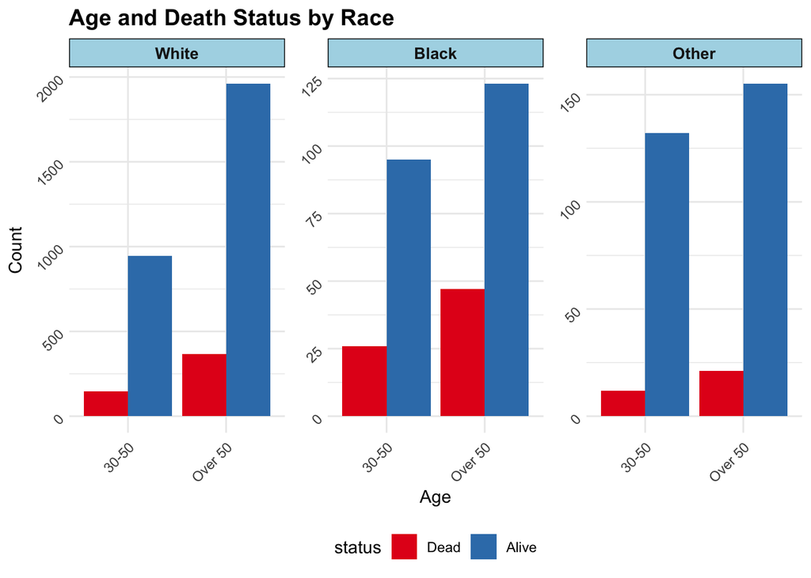

```r
# Convert numerical values to factors with appropriate labels
clean_data$race = factor(clean_data$race,
                         levels = c(0, 1, 2),
                         labels = c("White", "Black", "Other"))

clean_data$age = cut(clean_data$age,
                        breaks = c(-Inf, 30, 50, Inf),
                        labels = c("Under 30", "30-50", "Over 50"),
                        right = FALSE)

clean_data$status = factor(clean_data$status,
                            levels = c(0, 1),
                            labels = c("Dead", "Alive"))

# Group and summarize the data
summary_data_a = clean_data |>
  group_by(age, race, status) |>
  summarise(count = n(), .groups = "drop")

# Create a bar plot
ggplot(summary_data_a, aes(x = age, y = count, fill = status)) +
  geom_bar(stat = "identity", position = position_dodge()) +
  scale_fill_brewer(palette = "Set1") +
  facet_wrap(~race, scales = "free_y") +
  labs(title = "Age and Death Status by Race",
       x = "Age",
       y = "Count") +
  theme_minimal() +
  theme(legend.position = "bottom",
        axis.text = element_text(angle = 45, hjust = 1),
        plot.title = element_text(size = 14, face = "bold"),
        strip.background = element_rect(fill = "lightblue"),
        strip.text.x = element_text(size = 10, face = "bold"))
```

# race: marital status

# Predicting Risk of Death Using Covariates

Build a predictive model using variables 1-14 as covariates.

```r
covariates = clean_data[, 1:14]
outcome = clean_data$status

model_data = data.frame(covariates, outcome)

model = glm(outcome ~ ., data = model_data, family = "binomial")
```

# Identifying Significant Factors and Interactions

To identify significant factors and potential interactions:

```r
summary(model)
```

```
##
## Call:
## glm(formula = outcome ~ ., family = "binomial", data = model_data)
##
## Coefficients: (1 not defined because of singularities)
##                          Estimate Std. Error z value Pr(>|z|)
## (Intercept)             4.711e-01  2.390e-01   1.971 0.048713 *
## ...1                    5.064e-05  4.038e-05   1.254 0.209864
## ageOver 50             -2.730e-01  1.048e-01  -2.606 0.009174 **
## raceBlack              -4.753e-01  1.588e-01  -2.994 0.002756 **
## raceOther               4.403e-01  2.003e-01   2.198 0.027915 *
## marital_status         -1.387e-01  4.525e-02  -3.066 0.002167 **
## t_stage                -3.122e-01  1.181e-01  -2.642 0.008231 **
## n_stage                -6.767e-01  1.789e-01  -3.782 0.000156 ***
## x6th_stage             -6.657e-02  1.167e-01  -0.571 0.568308
## differentiate           4.232e-01  7.851e-02   5.390 7.04e-08 ***
## grade                          NA         NA      NA       NA
## a_stage                -6.157e-02  2.488e-01  -0.247 0.804545
## tumor_size              1.849e-03  3.347e-03   0.552 0.580755
## estrogen_status         6.977e-01  1.753e-01   3.981 6.87e-05 ***
## progesterone_status     5.710e-01  1.271e-01   4.493 7.01e-06 ***
## regional_node_examined  2.319e-02  6.467e-03   3.586 0.000336 ***
## ---
## Signif. codes:  0 '***' 0.001 '**' 0.01 '*' 0.05 '.' 0.1 ' ' 1
##
## (Dispersion parameter for binomial family taken to be 1)
##
##     Null deviance: 3444.7  on 4023  degrees of freedom
## Residual deviance: 2997.1  on 4009  degrees of freedom
## AIC: 3027.1
##
## Number of Fisher Scoring iterations: 5
```

```r
# race + age
race_marital_status_model_interaction = glm(outcome ~ . + race:marital_status, data = model_data, family = "binomial")
summary(race_marital_status_model_interaction)
```

```
##
## Call:
## glm(formula = outcome ~ . + race:marital_status, family = "binomial",
##     data = model_data)
##
## Coefficients: (1 not defined because of singularities)
##                            Estimate Std. Error z value Pr(>|z|)
## (Intercept)               4.407e-01  2.400e-01   1.836 0.066336 .
## ...1                      4.892e-05  4.041e-05   1.210 0.226109
## ageOver 50               -2.745e-01  1.049e-01  -2.617 0.008863 **
## raceBlack                -3.515e-01  2.213e-01  -1.589 0.112172
## raceOther                 7.022e-01  2.446e-01   2.871 0.004094 **
## marital_status           -9.851e-02  5.032e-02  -1.958 0.050277 .
## t_stage                  -3.091e-01  1.182e-01  -2.614 0.008959 **
## n_stage                  -6.911e-01  1.794e-01  -3.853 0.000117 ***
## x6th_stage               -6.040e-02  1.169e-01  -0.517 0.605234
## differentiate             4.293e-01  7.862e-02   5.460 4.75e-08 ***
## grade                            NA         NA      NA       NA
## a_stage                  -6.292e-02  2.493e-01  -0.252 0.800737
## tumor_size                1.700e-03  3.353e-03   0.507 0.612221
## estrogen_status           6.962e-01  1.758e-01   3.960 7.48e-05 ***
## progesterone_status       5.697e-01  1.272e-01   4.477 7.56e-06 ***
## regional_node_examined    2.319e-02  6.469e-03   3.585 0.000337 ***
## raceBlack:marital_status -1.248e-01  1.412e-01  -0.884 0.376956
## raceOther:marital_status -3.848e-01  1.733e-01  -2.221 0.026352 *
## ---
## Signif. codes:  0 '***' 0.001 '**' 0.01 '*' 0.05 '.' 0.1 ' ' 1
##
## (Dispersion parameter for binomial family taken to be 1)
##
##     Null deviance: 3444.7  on 4023  degrees of freedom
## Residual deviance: 2992.0  on 4007  degrees of freedom
## AIC: 3026
##
## Number of Fisher Scoring iterations: 5
```

**The interaction raceOther:marital_status is significant, suggesting that the combined effect of being of ‘Other’ race and marital status is different than their individual effects.**

**Model Comparison: The AIC for this model is 3026, slightly lower than the initial model, suggesting a marginally better fit with the inclusion of the interaction terms.**

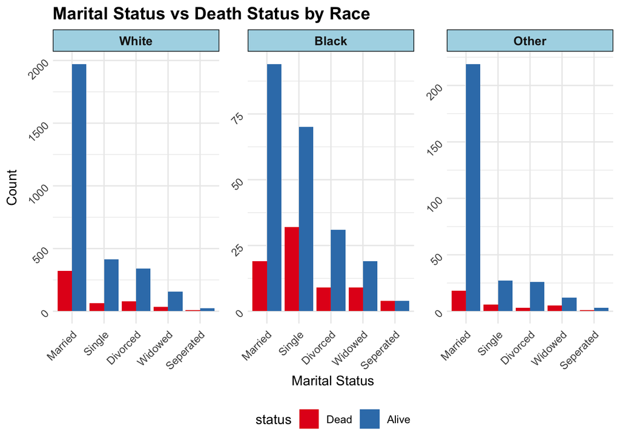

```r
# Convert numerical values to factors with appropriate labels


clean_data$marital_status = factor(clean_data$marital_status,
                                    levels = c(0, 1, 2, 3, 4),
                                    labels = c("Married", "Single", "Divorced", "Widowed", "Seperated"))


# Group and summarize the data
summary_data_b = clean_data |>
  group_by(marital_status, race, status) |>
  summarise(count = n(), .groups = "drop")

# Create a bar plot
ggplot(summary_data_b, aes(x = marital_status, y = count, fill = status)) +
  geom_bar(stat = "identity", position = position_dodge()) +
  scale_fill_brewer(palette = "Set1") +
  facet_wrap(~race, scales = "free_y") +
  labs(title = "Marital Status vs Death Status by Race",
       x = "Marital Status",
       y = "Count") +
  theme_minimal() +
  theme(legend.position = "bottom",
        axis.text = element_text(angle = 45, hjust = 1),
        plot.title = element_text(size = 14, face = "bold"),
        strip.background = element_rect(fill = "lightblue"),
        strip.text.x = element_text(size = 10, face = "bold"))
```